# Assignment 3

## Introduction + Summary Information

Many believe that the Civil Rights Act of 1964 marked the end of racism in the United States. The legislation did indeed outlaw explicit discriminatory practices on the basis of race, color, religion, sex and national origin, however racism has endured and manifested itself in more quiet and insidious form. The documentary, [13th](https://www.youtube.com/watch?v=krfcq5pF8u8), by *Ava DuVernay*, and book, [The New Jim Crow](https://newjimcrow.com), by *Michelle Alexander*, both explore the mass incarceration of African Americans, and the prison industrial complex as terrible manifestations of racism in the 20th century. Factors such as over-policing people of color and the war on drugs have all contributed heavily towards the disproportionate amount of people of color in prison systems.

This assignment serves to observe how data about county and incarcerated populations can highlight the patterns of inequalities present in our current jail and prison systems. I will be using the incarceration dataset, specifically `incarceration_trends.csv` provided by the [Vera Institute](https://github.com/vera-institute/incarceration-trends), in order to show patterns of inequality. In this project, I will be focusing upon the `black_jail_pop` (population of Black individuals in jail) variable(s) and performing analyses which highlight the disproportionate populations, by race, within our jail systems.

My summary analysis answers several questions & answers:

- What is the **average value** of the population of Black individuals jail across all the counties (in the most recent year)?

83.57426

- What is the **highest value** of the population of Black individuals in jail across all counties (in the most recent year)?

5024

- What county(s) and state(s) is the population of Black individuals in jail the **highest** (in the most recent year)?

Los Angeles County, CA

- What state(s) is the population of Black individuals in jail the **lowest** (in the most recent year)?

CT DE HI RI VT

- How much has the total population of Black individuals in jail across all counties and states **changed over the last 5 years**?

12943.57

## Trends Over Time Chart

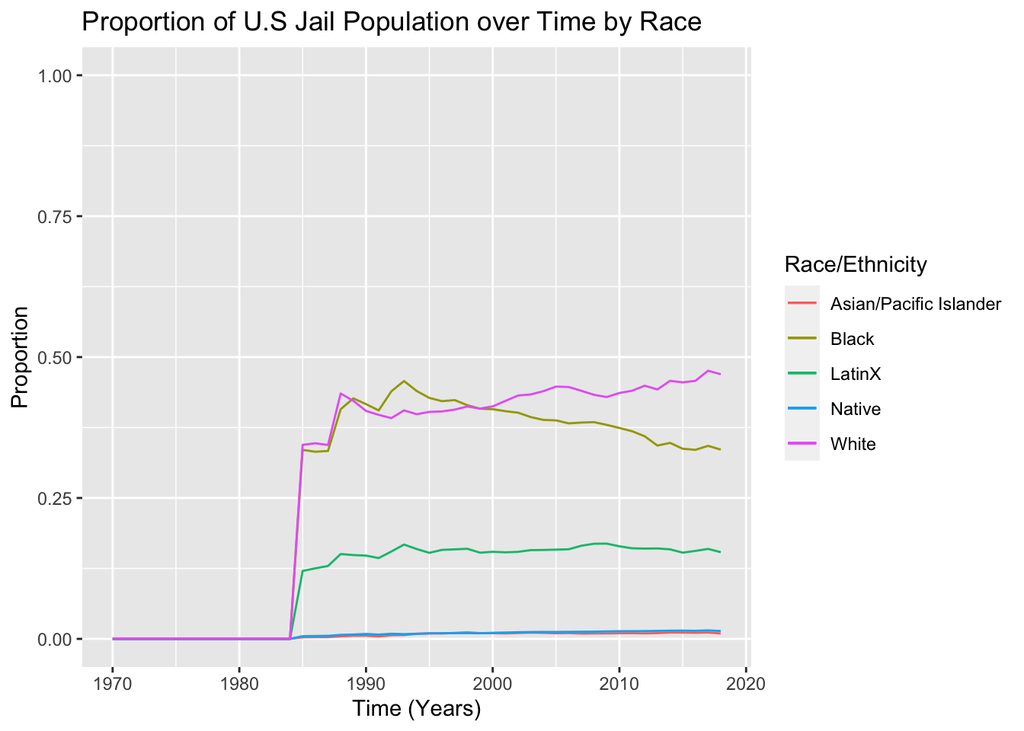

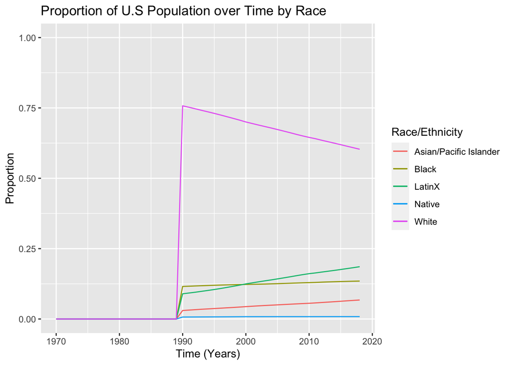

For my **trends over time chart**, I chose to include two line graphs that show the proportion of jail populations and the proportion of U.S populations over time, stratified by race. The reason I chose this chart is because it allows us to compare the proportions of populations by different groups of interest within a certain population, giving us meaningful insights. Specifically, it allows us to compare the proportion of populations in the jail to the general U.S population. Through these two graphs, we can see an alarming disparity between their proportions. Although black populations make up a small proportion of the U.S population, they make up around **40%** of the population in jail systems. The only group that has a similar proportion in jail populations are Whites, which are a majority group. This highlights a problem in the United States, as individuals who are Black are incarcerated at a similar rate as individuals who are White, although they make up a significantly smaller proportion of the total U.S population.

## Variable Comparison Chart

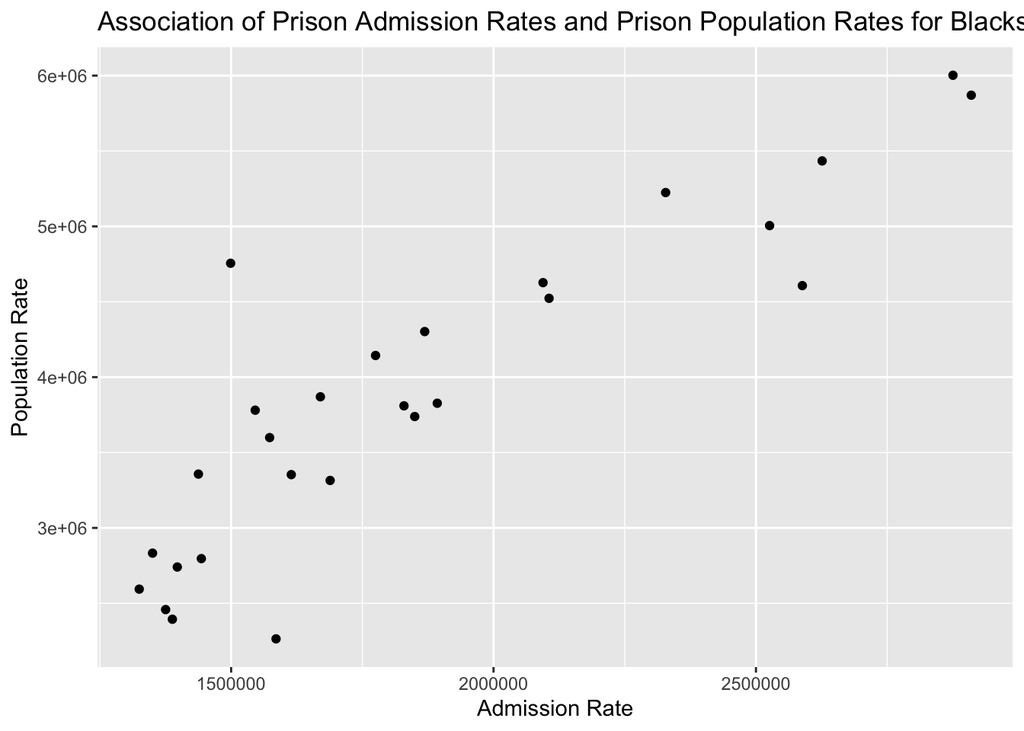

For my **variable comparison chart** I chose to compare two continuous variables: `black_prison_adm_rate` (prison admission rates for Black individuals) and `black_prison_pop_rate` (prison population rates for Black individuals). The reason I selected these variables is because it provides us with an opportunity to understand how increasing incarceration rates for Black individuals ultimately creates a disproportionate population in U.S. prisons. We can see through this scatterplot that there is a strong positive correlation between increasing prison admission rates for Black individuals, and an ever increasing prison population rate for Black individuals. This is an unfortunate pattern that continues to reinforce stereotypes and underlying forms of racism, continuously undermining Black individuals.

# Map

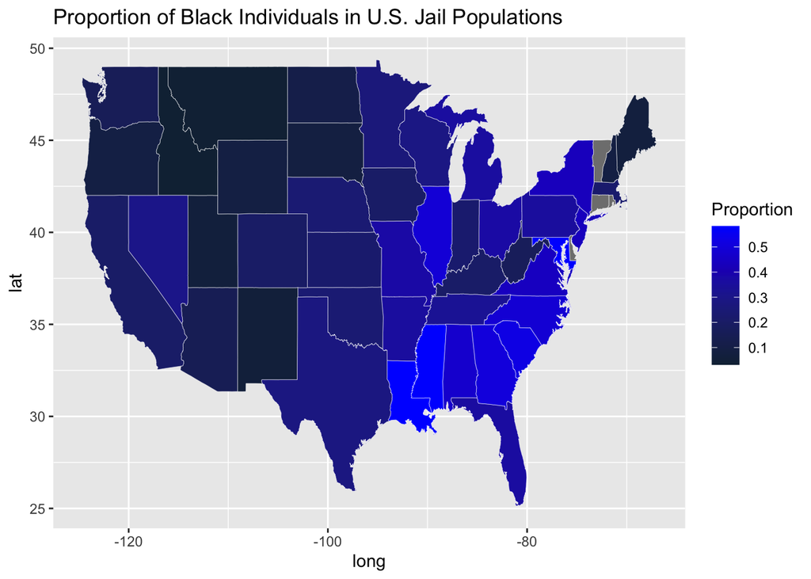